# models

[figure not shown]

M2.882 · Trabajo Final de Máster · Área 5

2023 - Máster universitario en Ciencias de datos (*Data science*)

Estudios de Informática, Multimedia y Telecomunicaciones

# Detección eficiente de anomalías en sensores de CO2 en tiempo real

### Javier Gallego Fernández

En esta notebook se incluyen todos los procesos llevados a cabo para la creación y evaluación de los modelos de detección de anomalías. Los apartados son los siguientes:

1 - Importación de librerías y carga de datos.

2 - Exploración inicial de los datos.

3 - Limpieza de datos.

4 - Análisis de datos.

5 - Preparación de los conjuntos de entrenamiento, validación y test.

6 - Modelo Cloud: LSTM-AE.

7 - Modelo Standalone: LSTM-AE.

8 - Isolation Forest

9 - OC-SVM

10 - Comparativa de modelos.

## 1 - IMPORTACIÓN DE LIBRERÍAS Y CARGA DE DATOS

En este apartado se importan todas las librerías utilizadas en el desarrollo del documento y se cargan los datos de los sensores de CO2. Al estar usando el entorno de *kaggle*, estamos limitados en cuanto a la ruta donde se encuentran los ficheros.

```python
import os
import numpy as np
import tensorflow as tf
import matplotlib.pyplot as plt
import seaborn as sns
import pandas as pd
import scipy
from scipy import stats
import sklearn
from sklearn import preprocessing
import joblib
import optuna
import optuna.visualization as optuna_visualization
from sklearn.impute import KNNImputer
from sklearn.metrics import classification_report,accuracy_score, roc_curve, auc
from sklearn.ensemble import IsolationForest
from sklearn.svm import OneClassSVM
from sklearn.model_selection import GridSearchCV
from pylab import rcParams
!pip install micromlgen
from micromlgen import port
RANDOM_SEED = 42
```

```
  Preparing metadata (setup.py) ... done
WARNING: Running pip as the 'root' user can result in broken permissions and conflicting behaviour with the system package manager. It is recommended to use a virtual environment instead: https://pip.pypa.io/warnings/venv
```

```python
albea_data = pd.read_csv('../input/co2-data/CEIP_LAlbea_ValldAbav2.csv')
santmiquel_data = pd.read_csv('../input/co2-data/CEIP_SantMiquel_Vilafames.csv')
```

## 2 - EXPLORACIÓN INICIAL

Este primer apartado sirve para hacernos una idea general de nuestros datos. Vamos a ver algunos registros de cada fuente de datos y algunas estadísticas generales del mismo.  
**Nota: En términos generales no se entrará a analizar cada código realizado ya que las conclusiones están recogidas en la memoria del TFM.**

```python
display(albea_data.head())
```

|  | published_at | date_time | date | month | w_day | time | hour | mint | sec | temp | hum | co2 | bat | sensor_id |
| --- | --- | --- | --- | --- | --- | --- | --- | --- | --- | --- | --- | --- | --- | --- |
| 0 | 2021-06-01T14:30:06.735Z | 2021-06-01T14:30:06 | 2021-06-01 | Jun | Tue | 14:30:06 | 14 | 30 | 6 | 29.84 | 46.33 | 390 | 85.19 | CO2_01 |
| 1 | 2021-06-01T14:15:06.784Z | 2021-06-01T14:15:06 | 2021-06-01 | Jun | Tue | 14:15:06 | 14 | 15 | 6 | 29.82 | 47.53 | 391 | 81.14 | CO2_01 |
| 2 | 2021-06-01T14:20:06.733Z | 2021-06-01T14:20:06 | 2021-06-01 | Jun | Tue | 14:20:06 | 14 | 20 | 6 | 29.83 | 47.24 | 391 | 82.49 | CO2_01 |
| 3 | 2021-06-01T14:35:06.728Z | 2021-06-01T14:35:06 | 2021-06-01 | Jun | Tue | 14:35:06 | 14 | 35 | 6 | 29.87 | 46.07 | 393 | 86.54 | CO2_01 |
| 4 | 2021-06-01T14:40:06.729Z | 2021-06-01T14:40:06 | 2021-06-01 | Jun | Tue | 14:40:06 | 14 | 40 | 6 | 29.96 | 45.92 | 395 | 87.90 | CO2_01 |

```python
display(santmiquel_data.head())
```

|  | published_at | date_time | date | month | w_day | hour | mint | sec | temp | hum | co2 | bat | sensor_id |
| --- | --- | --- | --- | --- | --- | --- | --- | --- | --- | --- | --- | --- | --- |
| 0 | 2021-05-03T07:00:05.241Z | 2021-05-03T07:00:05 | 5/3/2021 | May | Mon | 7 | 0 | 5 | 26.551460 | 39.382935 | 302 | 99.55 | CO2_06 |
| 1 | 2021-05-03T07:05:05.348Z | 2021-05-03T07:05:05 | 5/3/2021 | May | Mon | 7 | 5 | 5 | 26.479362 | 39.572144 | 301 | 99.55 | CO2_06 |
| 2 | 2021-05-03T07:20:05.162Z | 2021-05-03T07:20:05 | 5/3/2021 | May | Mon | 7 | 20 | 5 | 26.578163 | 40.089417 | 376 | 99.55 | CO2_06 |
| 3 | 2021-05-03T07:25:05.047Z | 2021-05-03T07:25:05 | 5/3/2021 | May | Mon | 7 | 25 | 5 | 26.749062 | 40.321350 | 520 | 99.55 | CO2_06 |
| 4 | 2021-05-03T07:35:04.554Z | 2021-05-03T07:35:04 | 5/3/2021 | May | Mon | 7 | 35 | 4 | 27.160294 | 39.421082 | 393 | 99.55 | CO2_06 |

```python
display(albea_data.describe())
```

|  | hour | mint | sec | temp | hum | co2 | bat |
| --- | --- | --- | --- | --- | --- | --- | --- |
| count | 34569.000000 | 34569.000000 | 34569.000000 | 3.456900e+04 | 34569.000000 | 34569.000000 | 34569.000000 |
| mean | 11.546675 | 27.514565 | 5.300761 | -3.934161e+11 | 44.581813 | 464.838439 | 94.460135 |
| std | 6.945308 | 17.268860 | 1.007263 | 7.314683e+13 | 6.836175 | 134.195014 | 12.983063 |
| min | 0.000000 | 0.000000 | 3.000000 | -1.360000e+16 | 21.040000 | 358.000000 | 0.000000 |
| 25% | 5.000000 | 10.000000 | 5.000000 | 2.872000e+01 | 40.820000 | 415.000000 | 95.570000 |
| 50% | 12.000000 | 30.000000 | 5.000000 | 3.000000e+01 | 45.310000 | 429.000000 | 96.340000 |
| 75% | 18.000000 | 45.000000 | 6.000000 | 3.129000e+01 | 49.370000 | 448.000000 | 98.070000 |
| max | 23.000000 | 55.000000 | 38.000000 | 4.446000e+01 | 64.180000 | 1989.000000 | 100.000000 |

```python
display(santmiquel_data.describe())
```

|  | hour | mint | sec | temp | hum | co2 | bat |
| --- | --- | --- | --- | --- | --- | --- | --- |
| count | 38890.000000 | 38890.000000 | 38890.000000 | 38890.000000 | 38890.000000 | 38890.000000 | 38890.000000 |
| mean | 11.614888 | 27.469555 | 5.497017 | 26.362428 | 41.705725 | 462.057136 | 90.565417 |
| std | 6.887407 | 17.254201 | 2.105269 | 1.942331 | 6.116020 | 75.125794 | 18.467512 |
| min | 0.000000 | 0.000000 | 0.000000 | 20.001144 | 14.300000 | 301.000000 | 0.000000 |
| 25% | 6.000000 | 10.000000 | 5.000000 | 25.100000 | 38.300000 | 417.000000 | 95.000000 |
| 50% | 12.000000 | 25.000000 | 5.000000 | 26.600000 | 42.600000 | 442.000000 | 95.570000 |
| 75% | 18.000000 | 40.000000 | 6.000000 | 27.800000 | 45.600000 | 479.000000 | 96.340000 |
| max | 23.000000 | 56.000000 | 59.000000 | 39.900000 | 63.900000 | 1213.000000 | 100.000000 |

## 3 - Limpieza de datos

En este apartado se realizan todos los procesos llevados a cabo para preparar los datos para su análisis y correcto funcionamiento en los modelos. En cada celda se incorporan comentarios que ayudan a comprender lo que se está realizando.

```python
# Agregamos una nueva columna que indica la ubicación de los datos y fusionamos las dos fuentes en una
albea_data['location'] = 'albea'
santmiquel_data['location'] = 'santmiquel'
final_dataset_total = pd.concat([santmiquel_data,albea_data])
```

```python
# Seleccionamos un subconjunto de los atributos que nos interesan para la limpieza y el análisis
final_dataset = final_dataset_total[['date_time', 'co2', 'sensor_id', 'month' , 'w_day', 'hour', 'location']]
```

```python
display(final_dataset.head())
```

|  | date_time | co2 | sensor_id | month | w_day | hour | location |
| --- | --- | --- | --- | --- | --- | --- | --- |
| 0 | 2021-05-03T07:00:05 | 302 | CO2_06 | May | Mon | 7 | santmiquel |
| 1 | 2021-05-03T07:05:05 | 301 | CO2_06 | May | Mon | 7 | santmiquel |
| 2 | 2021-05-03T07:20:05 | 376 | CO2_06 | May | Mon | 7 | santmiquel |
| 3 | 2021-05-03T07:25:05 | 520 | CO2_06 | May | Mon | 7 | santmiquel |
| 4 | 2021-05-03T07:35:04 | 393 | CO2_06 | May | Mon | 7 | santmiquel |

```python
# Vemos los sensores con los que cuenta cada ubicación
pd.set_option('display.max_colwidth', None)
display(final_dataset.groupby('location').sensor_id.unique())
```

```
location
albea         [ CO2_01,  CO2_02,  CO2_03,  CO2_04,  CO2_05,  CO2_06]
santmiquel    [ CO2_06,  CO2_04,  CO2_01,  CO2_03,  CO2_02,  CO2_05]
Name: sensor_id, dtype: object
```

```python
# Se muestra el tipo de dato de cada atributo del DataFrame
display(final_dataset.dtypes)
```

```
date_time    object
co2           int64
sensor_id    object
month        object
w_day        object
hour          int64
location     object
dtype: object
```

```python
# Convertimos el atributo date_time a tipo datetime para trabajar con él de una manera más cómoda y efectiva
final_dataset['date_time'] = pd.to_datetime(final_dataset['date_time'])
```

```python
# Volvemos a mostrar el tipo de datos para ver que se ha realizado correctamente el cambio
display(final_dataset.dtypes)
```

```
date_time    datetime64[ns]
co2                   int64
sensor_id            object
month                object
w_day                object
hour                  int64
location             object
dtype: object
```

```python
# Eliminamos los espacios en blanco al principio y al final del atributo sensor_id
final_dataset.sensor_id = final_dataset.sensor_id.apply(lambda x: x.strip())
```

#### Vamos a eliminar los registros duplicados.

```python
# Primero observamos el número total de registros antes de limpiar los registros duplicados
final_dataset.date_time.count()
```

```
73459
```

```python
# Ponemos los segundos a 0 de la variable date_time, ya que la precisión con la que queremos eliminar los duplicados es de minutos.
final_dataset.date_time = final_dataset.date_time.dt.floor('min')
```

```python
# Eliminamos los duplicados manteniendo la primera aparición. Un duplicado es aquel que comparte fecha (date_time), sensor (sensor_id) y ubicación (location)
final_dataset.drop_duplicates(subset=['date_time', 'sensor_id', 'location'], keep='first', inplace = True)
```

```python
# Volvemos a imprimir el número de registros para ver cuantos se han eliminado
final_dataset.date_time.count()
```

```
72877
```

#### Se han eliminado un total de 582 registros duplicados

```python
# Vemos si existen valores nulos, en este caso NO tenemos valores nulos en nuestros datos
final_dataset.isna().sum(axis = 0)
```

```
date_time    0
co2          0
sensor_id    0
month        0
w_day        0
hour         0
location     0
dtype: int64
```

```python
# Vemos los valores máximos y mínimos de CO2 para comprobar si existen errores de medición. Valores igual a 0 o otros extremadamente grandes.
print(final_dataset.co2.max())
print(final_dataset.co2.min())
```

```
1989
301
```

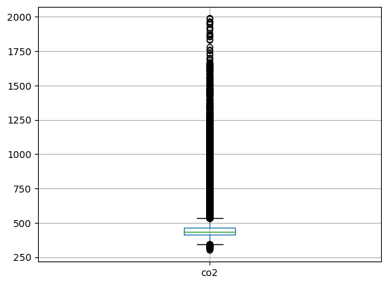

```python
# Creamos un boxplot con la misma finalidad y para hacernos una idea de la distribución de los datos
final_dataset.boxplot(column='co2')
```

```python
# Ordenamos los datos de cada ubicación por sensor y por fecha
final_dataset.sort_values(['location', 'sensor_id', 'date_time'], inplace=True)
```

```python
# Vamos a ver un resumen de los datos
display(final_dataset.describe(include=["object", "datetime64", "int"]))
```

|  | date_time | co2 | sensor_id | month | w_day | hour | location |
| --- | --- | --- | --- | --- | --- | --- | --- |
| count | 72877 | 72877.000000 | 72877 | 72877 | 72877 | 72877.000000 | 72877 |
| unique | 14685 | NaN | 6 | 2 | 7 | NaN | 2 |
| top | 2021-05-25 16:15:00 | NaN | CO2_02 | May | Fri | NaN | santmiquel |
| freq | 6 | NaN | 12948 | 38477 | 10920 | NaN | 38477 |
| first | 2021-05-03 07:00:00 | NaN | NaN | NaN | NaN | NaN | NaN |
| last | 2021-06-23 23:55:00 | NaN | NaN | NaN | NaN | NaN | NaN |
| mean | NaN | 463.413697 | NaN | NaN | NaN | 11.577288 | NaN |
| std | NaN | 107.279452 | NaN | NaN | NaN | 6.913305 | NaN |
| min | NaN | 301.000000 | NaN | NaN | NaN | 0.000000 | NaN |
| 25% | NaN | 416.000000 | NaN | NaN | NaN | 6.000000 | NaN |
| 50% | NaN | 434.000000 | NaN | NaN | NaN | 12.000000 | NaN |
| 75% | NaN | 464.000000 | NaN | NaN | NaN | 18.000000 | NaN |
| max | NaN | 1989.000000 | NaN | NaN | NaN | 23.000000 | NaN |

## 4 - Análisis de datos

En esta fase se realiza el proceso de análisis de datos, con la finalidad de entenderlos en profundidad y sacar conclusiones útiles para la fase de creación de los modelos.

```python
# Vamos a ver la cantidad de datos de cada sensor de CO2
sensor_counts = final_dataset.groupby('location').sensor_id.value_counts()
print(sensor_counts)
```

```
location    sensor_id
albea       CO2_03       6218
            CO2_01       6164
            CO2_06       6119
            CO2_02       6101
            CO2_05       5582
            CO2_04       4216
santmiquel  CO2_04       7474
            CO2_02       6847
            CO2_06       6789
            CO2_01       6587
            CO2_05       6095
            CO2_03       4685
Name: sensor_id, dtype: int64
```

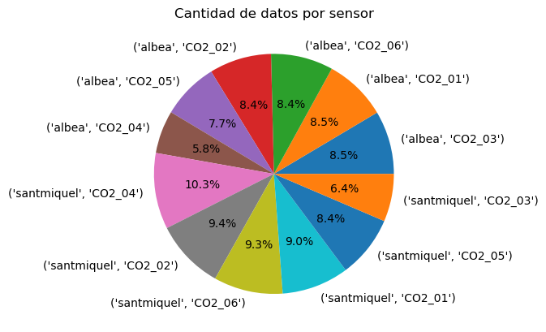

```python
# Mostramos los datos anteriores en términos porcentuales y en un gráfico de sectores
plt.pie(sensor_counts.values, labels=sensor_counts.index, autopct='%1.1f%%')
plt.title('Cantidad de datos por sensor')
plt.show()
```

### Rangos de fechas, días y horas

Mostramos los rangos de estos atributos para comprender la temporalidad de los datos con los que contamos

```python
# Vemos el rango de fechas
print(final_dataset.date_time.min())
print(final_dataset.date_time.max())
```

```
2021-05-03 07:00:00
2021-06-23 23:55:00
```

```python
# Vemos el rango de días de la semana y la cantidad de datos de cada día
w_day_counts = final_dataset.w_day.value_counts()
print(w_day_counts)
```

```
Fri    10920
Tue    10871
Wed    10845
Thu    10579
Sat    10077
Mon    10061
Sun     9524
Name: w_day, dtype: int64
```

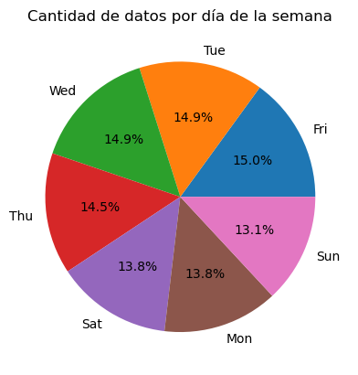

```python
# Creamos un gráfico de sectores con el porcentaje de datos de cada día de la semana
plt.pie(w_day_counts.values, labels=w_day_counts.index, autopct='%1.1f%%')
plt.title('Cantidad de datos por día de la semana')
plt.show()
```

```python
# Obsevamos como se distribuyen los datos en función de la hora de medición
final_dataset.hour.describe()
```

```
count    72877.000000
mean        11.577288
std          6.913305
min          0.000000
25%          6.000000
50%         12.000000
75%         18.000000
max         23.000000
Name: hour, dtype: float64
```

### Determinar cada cuanto se toman los datos

```python
# Vemos el principio del DataFrame ordenado para ver el tiempo de separación de los registros
final_dataset.head(10)
```

|  | date_time | co2 | sensor_id | month | w_day | hour | location |
| --- | --- | --- | --- | --- | --- | --- | --- |
| 149 | 2021-06-01 00:00:00 | 466 | CO2_01 | Jun | Tue | 0 | albea |
| 148 | 2021-06-01 00:05:00 | 466 | CO2_01 | Jun | Tue | 0 | albea |
| 142 | 2021-06-01 00:10:00 | 465 | CO2_01 | Jun | Tue | 0 | albea |
| 150 | 2021-06-01 00:15:00 | 466 | CO2_01 | Jun | Tue | 0 | albea |
| 138 | 2021-06-01 00:20:00 | 463 | CO2_01 | Jun | Tue | 0 | albea |
| 130 | 2021-06-01 00:25:00 | 458 | CO2_01 | Jun | Tue | 0 | albea |
| 123 | 2021-06-01 00:30:00 | 454 | CO2_01 | Jun | Tue | 0 | albea |
| 124 | 2021-06-01 00:35:00 | 455 | CO2_01 | Jun | Tue | 0 | albea |
| 129 | 2021-06-01 00:40:00 | 458 | CO2_01 | Jun | Tue | 0 | albea |
| 128 | 2021-06-01 00:45:00 | 458 | CO2_01 | Jun | Tue | 0 | albea |

```python
# Hacemos lo mismo con el final del DataFrame
final_dataset.tail(10)
```

|  | date_time | co2 | sensor_id | month | w_day | hour | location |
| --- | --- | --- | --- | --- | --- | --- | --- |
| 38830 | 2021-05-31 10:25:00 | 407 | CO2_06 | May | Mon | 10 | santmiquel |
| 38833 | 2021-05-31 10:30:00 | 451 | CO2_06 | May | Mon | 10 | santmiquel |
| 38839 | 2021-05-31 10:35:00 | 453 | CO2_06 | May | Mon | 10 | santmiquel |
| 38845 | 2021-05-31 10:40:00 | 454 | CO2_06 | May | Mon | 10 | santmiquel |
| 38849 | 2021-05-31 10:45:00 | 450 | CO2_06 | May | Mon | 10 | santmiquel |
| 38856 | 2021-05-31 10:50:00 | 443 | CO2_06 | May | Mon | 10 | santmiquel |
| 38861 | 2021-05-31 10:55:00 | 446 | CO2_06 | May | Mon | 10 | santmiquel |
| 38873 | 2021-05-31 11:05:00 | 496 | CO2_06 | May | Mon | 11 | santmiquel |
| 38879 | 2021-05-31 11:10:00 | 418 | CO2_06 | May | Mon | 11 | santmiquel |
| 38885 | 2021-05-31 11:15:00 | 412 | CO2_06 | May | Mon | 11 | santmiquel |

#### Vemos que los datos se toman cada 5 minutos.

### Análisis temporal

El objetivo de este apartado es comprobar como afectan los aspectos temporales en las medidas de CO2

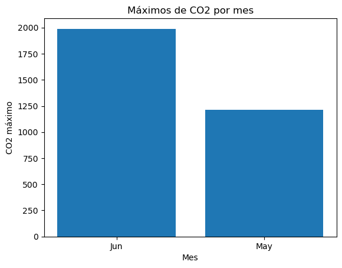

```python
# Representamos los valores máximos de CO2 en cada mes
max_value_by_month = final_dataset.groupby('month').co2.max()
plt.bar(max_value_by_month.index, max_value_by_month.values)
plt.xlabel('Mes')
plt.ylabel('CO2 máximo')
plt.title('Máximos de CO2 por mes')
plt.show()
```

```python
# Vamos a ver en que rango de fechas se sitúan las mediciones de cada localización
print(final_dataset[final_dataset.location == 'albea'].date_time.min())
print(final_dataset[final_dataset.location == 'albea'].date_time.max())
print(final_dataset[final_dataset.location == 'santmiquel'].date_time.min())
print(final_dataset[final_dataset.location == 'santmiquel'].date_time.max())
```

```
2021-06-01 00:00:00
2021-06-23 23:55:00
2021-05-03 07:00:00
2021-05-31 11:15:00
```

#### Se observa que los datos de Sant Miquel se tomaron en el mes de Mayo y los de Albea en Junio.

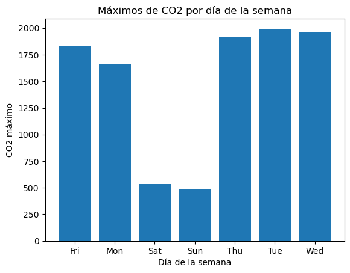

```python
# Representamos los máximos de CO2 en cada día de la semana
max_value_by_day = final_dataset.groupby('w_day').co2.max()
plt.bar(max_value_by_day.index, max_value_by_day.values)
plt.xlabel('Día de la semana')
plt.ylabel('CO2 máximo')
plt.title('Máximos de CO2 por día de la semana')
plt.show()
```

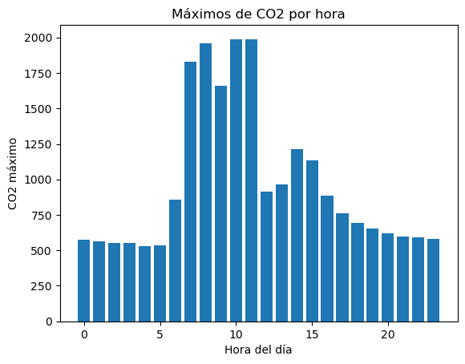

```python
# Representamos los máximos de CO2 en cada hora del día
max_value_by_hour = final_dataset.groupby('hour').co2.max()
plt.bar(max_value_by_hour.index, max_value_by_hour.values)
plt.xlabel('Hora del día')
plt.ylabel('CO2 máximo')
plt.title('Máximos de CO2 por hora')
plt.show()
```

#### Queremos ver si es habitual tener valores elevados en las horas previas al comienzo de las clases (7-8)

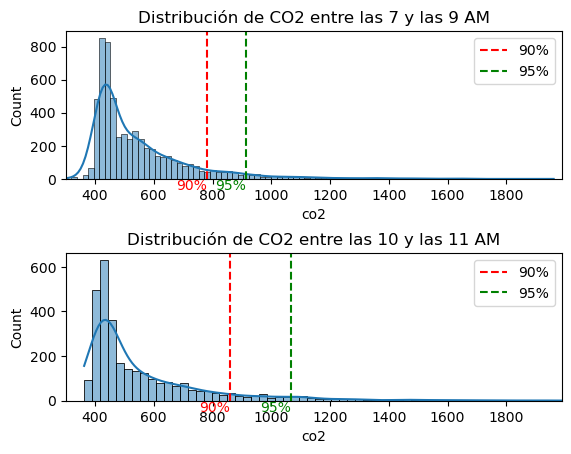

```python
# Creamos dos datasets. El primero tiene datos de las horas previas al comienzo de las clases (7-8) y el segundo de una hora en la que se están impartiendo clases (10)
data1 = final_dataset[(final_dataset.hour == 7) | (final_dataset.hour == 8)].co2
data2 = final_dataset[final_dataset.hour == 10].co2

# Sacamos los rangos de CO2 máximos y mínimos para igualar los ejes de ambos gráficos
x_range_max = max(max(data1), max(data2))
x_range_min = min(min(data1), min(data2))
fig, (ax1, ax2) = plt.subplots(2)
plt.subplots_adjust(hspace=0.5)
ax1.set_xlim(x_range_min, x_range_max)
ax2.set_xlim(x_range_min, x_range_max)

# Creamos los dos histogramas
sns.histplot(data1, kde=True, ax=ax1)
ax1.set_title('Distribución de CO2 entre las 7 y las 9 AM')

sns.histplot(data2, kde=True, ax=ax2)
ax2.set_title('Distribución de CO2 entre las 10 y las 11 AM')

# Calculamos los percentiles 90 y 95 para cada dataset
percentile_90_data1 = np.percentile(data1, 90)
percentile_95_data1 = np.percentile(data1, 95)

percentile_90_data2 = np.percentile(data2, 90)
percentile_95_data2 = np.percentile(data2, 95)

# Añadimos una franja para cada percentil calculado anteriormente
ax1.axvline(percentile_90_data1, color='r', linestyle='--', label='90%')
ax1.text(percentile_90_data1, 0, '90%', verticalalignment='top', horizontalalignment='right', color='r')
ax1.axvline(percentile_95_data1, color='g', linestyle='--', label='95%')
ax1.text(percentile_95_data1, 0, '95%', verticalalignment='top', horizontalalignment='right', color='g')

ax2.axvline(percentile_90_data2, color='r', linestyle='--', label='90%')
ax2.text(percentile_90_data2, 0, '90%', verticalalignment='top', horizontalalignment='right', color='r')
ax2.axvline(percentile_95_data2, color='g', linestyle='--', label='95%')
ax2.text(percentile_95_data2, 0, '95%', verticalalignment='top', horizontalalignment='right', color='g')

ax1.legend()
ax2.legend()

plt.show()
```

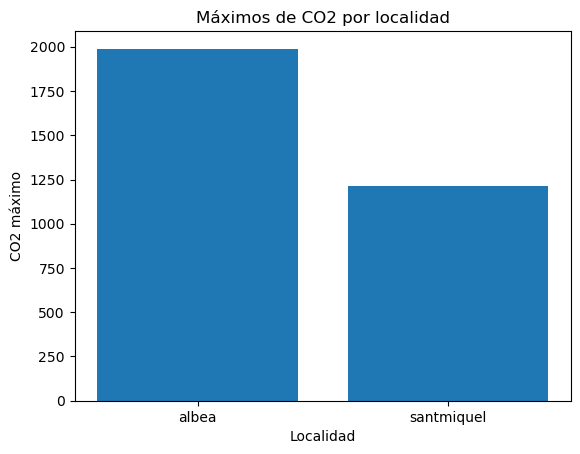

```python
# Representamos los máximos de CO2 para cada localidad
max_value_by_location = final_dataset.groupby('location').co2.max()
plt.bar(max_value_by_location.index, max_value_by_location.values)
plt.xlabel('Localidad')
plt.ylabel('CO2 máximo')
plt.title('Máximos de CO2 por localidad')
plt.show()
```

### Análisis de normalidad

Se puede asimir normalidad por la cantidad de datos de cada sensor (TLC), pero aún así se profundiza en esto mediante distintas técnicas.

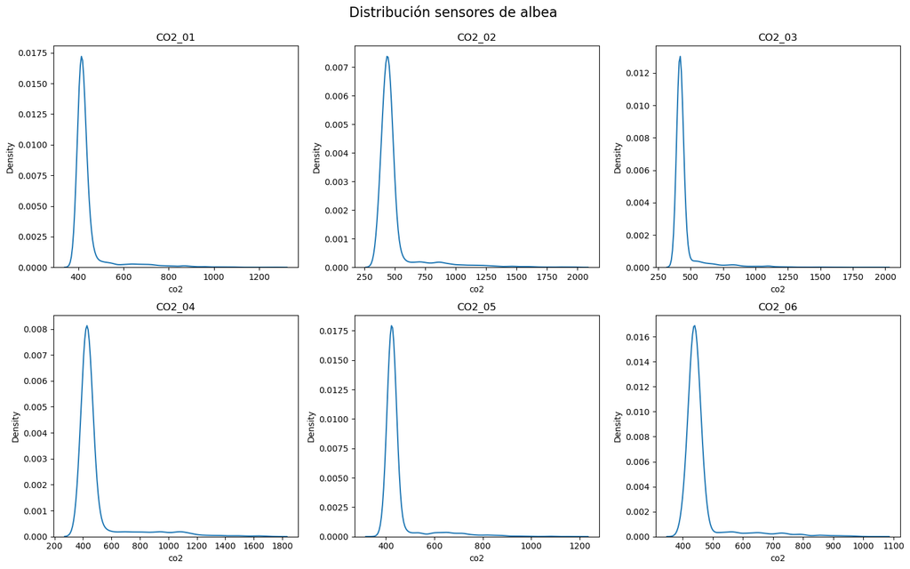

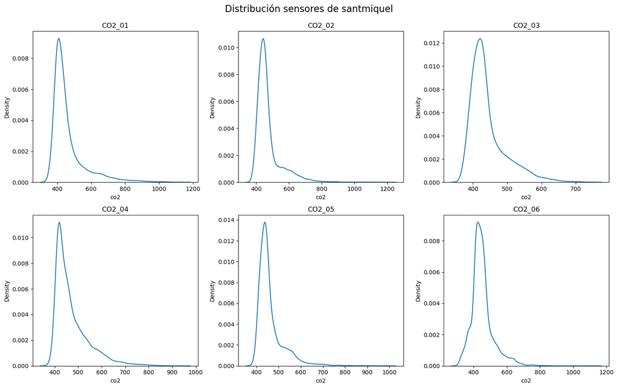

```python
# Realizamos los gráficos de densidad para cada sensor
# Primero iteramos cada localización
locations = final_dataset.location.unique()
for location in locations:
    # Para cada localización iteramos sus sensores
    sensors = final_dataset[final_dataset['location'] == location].sensor_id.unique()
    fig, axs = plt.subplots(2, 3, figsize=(15, 10))
    for i, sensor in enumerate(sensors):
        row = i // 3
        col = i % 3
        column = final_dataset[(final_dataset['location'] == location) & (final_dataset['sensor_id'] == sensor)].co2
        # Creamos el gráfico de densidad de los datos del sensor en cuestión
        sns.kdeplot(column, ax=axs[row, col])
        axs[row, col].set_title(sensor)

    fig.tight_layout(rect=[0, 0.05, 1, 0.95])
    fig.suptitle("Distribución sensores de " + str(location),  fontsize=16)
    plt.show()
```

```python
# Realizamos el test de Shapiro-Wilk para los datos de CO2 de cada sensor
locations = final_dataset.location.unique()
for location in locations:
    sensors = final_dataset[final_dataset['location'] == location].sensor_id.unique()
    for sensor in sensors:
        column = final_dataset[(final_dataset['location'] == location) & (final_dataset['sensor_id'] == sensor)].co2
        stat, p = stats.shapiro(column)
        print("Sensor " + str(sensor) + " - " + str(location) + ": " + str(p) + " (p-value)")
```

```
Sensor CO2_01 - albea: 0.0 (p-value)
Sensor CO2_02 - albea: 0.0 (p-value)
Sensor CO2_03 - albea: 0.0 (p-value)
Sensor CO2_04 - albea: 0.0 (p-value)
Sensor CO2_05 - albea: 0.0 (p-value)
Sensor CO2_06 - albea: 0.0 (p-value)
Sensor CO2_01 - santmiquel: 0.0 (p-value)
Sensor CO2_02 - santmiquel: 0.0 (p-value)
Sensor CO2_03 - santmiquel: 0.0 (p-value)
Sensor CO2_04 - santmiquel: 0.0 (p-value)
Sensor CO2_05 - santmiquel: 0.0 (p-value)
Sensor CO2_06 - santmiquel: 0.0 (p-value)
```

### Correlación entre variables

Por último, vamos a ver si existen correlaciones entre las variables numéricas de nuestro dataset. Utilizamos la **correlación de Spearman** porque nuestros datos no siguen una distribución normal.

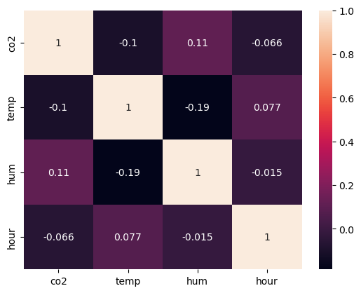

```python
# Creamos la matriz de correlación de los atributos que nos interesan
corr_matrix = final_dataset_total[['date_time', 'co2', 'temp', 'hum', 'sensor_id', 'month' , 'w_day', 'hour', 'location']].corr(method='spearman')
# Representamos la matriz de correlación en un mapa de calor
sns.heatmap(corr_matrix, annot=True)
```

## 5 - Preparación de los conjuntos de entrenamiento, validación y test

Tras el análisis, vamos a preparar los conjuntos para los modelos.

#### En nuestros datos pueden faltar registros, por lo que en algunos casos puede que no se tengan intervalos constantes de 5 minutos

```python
# Elegimos un sensor para comprobar la cantidad de registros que tiene y compararla con la cantidad teórica si los intervalos de 5 minutos fuesen constantes
data_before = final_dataset[(final_dataset.location == 'albea') & (final_dataset.sensor_id == 'CO2_04')]
# Creamos el rango teórico con una frecuencia de 5 minutos
time_range = pd.date_range(start=data_before.date_time.min(), end=data_before.date_time.max(), freq='5min')
num_data_points = len(time_range)
print("Teórico: " + str(num_data_points))
print("Real: " + str(data_before.date_time.count()))
```

```
Teórico: 6331
Real: 4216
```

#### Se decide utilizar interpolación lineal para rellenar los datos faltantes

```python
# Creamos un DataFrame vacío para guardar el nuevo dataset completo
final_dataset_full = pd.DataFrame(columns=final_dataset.columns.tolist())
# Recorremos todos los sensores
locations = final_dataset.location.unique()
for location in locations:
    sensors = final_dataset.sensor_id.unique()
    for sensor in sensors:
        data = final_dataset[(final_dataset.location == location) & (final_dataset.sensor_id == sensor)]
        # Calculamos el rango completo de tiempo y creamos un DataFrame
        full_range_date_time = pd.date_range(start=data['date_time'].min(), end=data['date_time'].max(), freq='5min')
        df_full = pd.DataFrame({'date_time': full_range_date_time})
        # Combinamos el DataFrame completo con el que tenemos del sensor para añadir las filas que faltan
        df_combined = pd.merge(df_full, data, on='date_time', how='left')
        # Utilizamos interpolación lineal para rellenar los valores faltantes
        df_combined['co2'] = df_combined['co2'].interpolate(method='linear')
        # Tenemos que rellenar también los datos del sensor y la ubación
        df_combined['sensor_id'] = sensor
        df_combined['location'] = location
        final_dataset_full = final_dataset_full.append(df_combined, ignore_index=True)
```

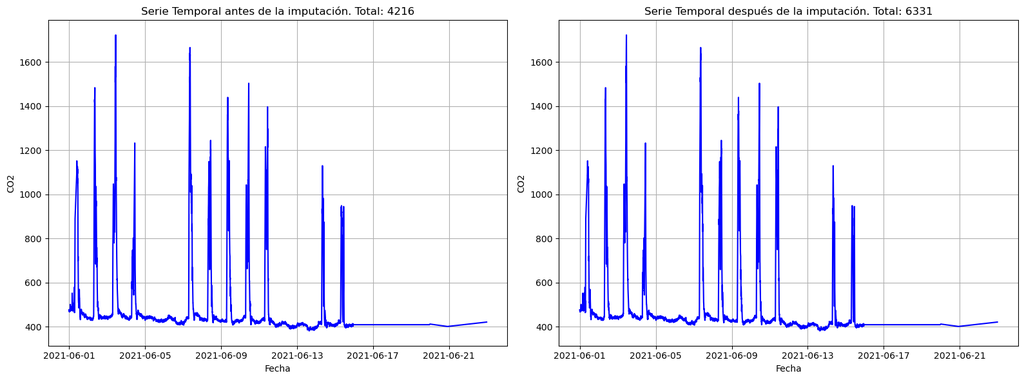

```python
# Vamos a representar el sensor analizado anteriormente. A la izquierda tenemos la serie temporal antes de la imputación y a la derecha después
data_after = final_dataset_full[(final_dataset_full.location == 'albea') & (final_dataset_full.sensor_id == 'CO2_04')]
fig, axes = plt.subplots(nrows=1, ncols=2, figsize=(16, 6))

# Gráfico de la serie temporal de CO2 antes de la imputación
axes[0].plot(data_before['date_time'], data_before['co2'], color='blue')
axes[0].set_xlabel('Fecha')
axes[0].set_ylabel('CO2')
axes[0].set_title('Serie Temporal antes de la imputación. Total: ' + str(data_before['co2'].count()))
axes[0].grid(True)

# Gráfico de la serie temporal de CO2 después de la imputación
axes[1].plot(data_after['date_time'], data_after['co2'], color='blue')
axes[1].set_xlabel('Fecha')
axes[1].set_ylabel('CO2')
axes[1].set_title('Serie Temporal después de la imputación. Total: ' + str(data_after['co2'].count()))
axes[1].grid(True)

plt.tight_layout()
plt.show()
```

#### Para el proceso de evaluación de resultados, es necesario etiquetar nuestros datos. Para ello vamos a definir un umbral a partir del cuál los datos serán anomalías. La Regla 3-sigma asume una distribución normal, por lo que usamos la Regla 3(IQR)

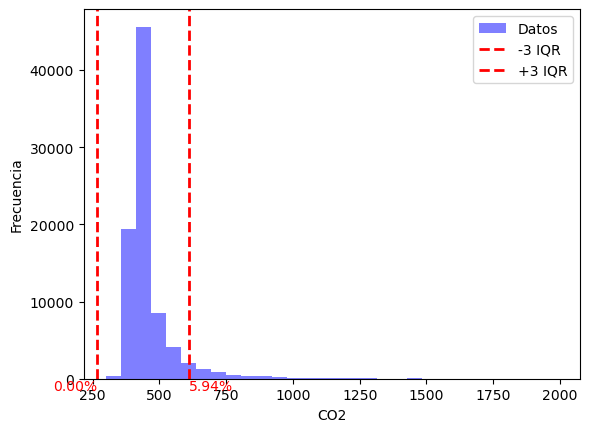

```python
data = final_dataset_full.co2 # Sacamos la secuencia de valores de CO2

# Calculamos el cuartil 1 y el cuartil 3

q1 = np.percentile(data, 25)
q3 = np.percentile(data, 75)

# Definimos los límites superior e inferior
lower_limit = q1 - 3 * (q3-q1)
upper_limit = q3 + 3 * (q3-q1)

# Calculamos el porcentaje de datos de CO2 por encima y por debajo del umbral
percentage_above = np.sum(data > upper_limit) / len(data) * 100
percentage_below = np.sum(data < lower_limit) / len(data) * 100

# Creamos el histograma
plt.hist(data, bins=30, alpha=0.5, color='blue', label='Datos')

# Vamos a pintar una línea vertical en los límites
plt.axvline(lower_limit, color='red', linestyle='--', linewidth=2, label='-3 IQR')
plt.axvline(upper_limit, color='red', linestyle='--', linewidth=2, label='+3 IQR')
plt.text(lower_limit, 10, f'{percentage_below:.2f}%', color='red', ha='right', va='top')
plt.text(upper_limit, 10, f'{percentage_above:.2f}%', color='red', ha='left', va='top')

plt.xlabel('CO2')
plt.ylabel('Frecuencia')
plt.legend()

plt.show()
```

```python
# Sacamos el valor del umbral superior
q1 = np.percentile(data, 25)
q3 = np.percentile(data, 75)
umbral = q3 + 3 * (q3-q1)
print(umbral)
```

```
611.0
```

```python
# Creamos una función que determine si un registro es una anomalía
def label_anomaly(row, umbral):
    if row.co2 <= umbral:
        return int(0)
    else:
        return int(1)
```

```python
# Aplicamos la función creada a nuestro dataset
final_dataset_full['target'] = final_dataset_full.apply(lambda row: label_anomaly(row, umbral), axis=1)
```

```python
final_dataset_full.describe()
```

|  | co2 | hour | target |
| --- | --- | --- | --- |
| count | 84068.000000 | 72872.000000 | 84068.000000 |
| mean | 462.501850 | 11.576888 | 0.059357 |
| std | 107.935109 | 6.913329 | 0.236293 |
| min | 301.000000 | 0.000000 | 0.000000 |
| 25% | 415.000000 | 6.000000 | 0.000000 |
| 50% | 434.000000 | 12.000000 | 0.000000 |
| 75% | 464.000000 | 18.000000 | 0.000000 |
| max | 1989.000000 | 23.000000 | 1.000000 |

**El siguiente paso es decidir que datos formarán parte de cada conjunto. Tenemos un total de 12 sensores, vamos a usar 6,2,4 para train, validación y test respectivamente. Esto quiere decir que vamos a entrenar nuestro modelo con los sensores de Sant Miquel y utilizar los de Albea para validación y test. Además, para los modelos LSTM-AE necesitamos eliminar las anomalías para el entrenamiento.**

```python
# Definimos una función que limpie las anomalías para los conjuntos de train y val
def clean_anomalies(data, threshold):
    df = pd.DataFrame(columns=data.columns.tolist())
    sensors = data.sensor_id.unique()
    for sensor in sensors:
        print("Sensor: " + str(sensor))
        sensor_data = data[(data.sensor_id == sensor)]
        anomalies = sensor_data[sensor_data['target'] == 1].co2.count()
        while anomalies > 0: # Proceso iterativo que se realiza hasta que no existan anomalías
            df_imputed = sensor_data.copy()
            # Creamos un imputador KNN de sklearn con 5 vecinos
            imputer = KNNImputer(n_neighbors=5)
            # Elinamos los valores de CO2 que son anomalías
            df_imputed.loc[df_imputed.target == 1, 'co2'] = np.nan
            # Realizamos la imputación
            co2_imputed = imputer.fit_transform(df_imputed.co2.values.reshape(-1, 1))
            df_imputed['co2_imputed'] = co2_imputed
            # Para los registros con anomalías guardamos los valores imputados
            df_imputed.loc[df_imputed['target'] == 1, 'co2'] = df_imputed.loc[df_imputed['target'] == 1, 'co2_imputed']
            # Recalculamos el número de anomalías presentes en los datos del sensor
            df_imputed['target'] = df_imputed.apply(lambda row: label_anomaly(row, threshold), axis=1)
            anomalies = df_imputed[df_imputed['target'] == 1].co2.count()
        df = df.append(df_imputed, ignore_index=True)
    return df
```

```python
# Los datos de Sant Miquel se utilizarán para el entrenamiento, por lo que debemos limpiar las anomalías
santmiquel_data_normal = clean_anomalies(final_dataset_full[final_dataset_full['location'] == 'santmiquel'], umbral)

# Lo mismo para los sensores de Albea que se utilizarán para la validación
val_selection = final_dataset_full[(final_dataset_full['location'] == 'albea') & ((final_dataset_full['sensor_id'] == 'CO2_01')
                                                                                  | (final_dataset_full['sensor_id'] == 'CO2_02'))]
albea_data_normal_01_02 = clean_anomalies(val_selection, umbral)
```

```
Sensor: CO2_01
Sensor: CO2_02
Sensor: CO2_03
Sensor: CO2_04
Sensor: CO2_05
Sensor: CO2_06
Sensor: CO2_01
Sensor: CO2_02
```

```python
santmiquel_data_normal.head()
```

|  | date_time | co2 | sensor_id | month | w_day | hour | location | target | co2_imputed |
| --- | --- | --- | --- | --- | --- | --- | --- | --- | --- |
| 0 | 2021-05-06 08:55:00 | 437.528975 | CO2_01 | May | Thu | 8.0 | santmiquel | 0 | 437.528975 |
| 1 | 2021-05-06 09:00:00 | 437.528975 | CO2_01 | May | Thu | 9.0 | santmiquel | 0 | 437.528975 |
| 2 | 2021-05-06 09:05:00 | 437.528975 | CO2_01 | May | Thu | 9.0 | santmiquel | 0 | 437.528975 |
| 3 | 2021-05-06 09:10:00 | 597.000000 | CO2_01 | NaN | NaN | NaN | santmiquel | 0 | 597.000000 |
| 4 | 2021-05-06 09:15:00 | 560.000000 | CO2_01 | May | Thu | 9.0 | santmiquel | 0 | 560.000000 |

```python
albea_data_normal_01_02.head()
```

|  | date_time | co2 | sensor_id | month | w_day | hour | location | target | co2_imputed |
| --- | --- | --- | --- | --- | --- | --- | --- | --- | --- |
| 0 | 2021-06-01 00:00:00 | 466.0 | CO2_01 | Jun | Tue | 0.0 | albea | 0 | 466.0 |
| 1 | 2021-06-01 00:05:00 | 466.0 | CO2_01 | Jun | Tue | 0.0 | albea | 0 | 466.0 |
| 2 | 2021-06-01 00:10:00 | 465.0 | CO2_01 | Jun | Tue | 0.0 | albea | 0 | 465.0 |
| 3 | 2021-06-01 00:15:00 | 466.0 | CO2_01 | Jun | Tue | 0.0 | albea | 0 | 466.0 |
| 4 | 2021-06-01 00:20:00 | 463.0 | CO2_01 | Jun | Tue | 0.0 | albea | 0 | 463.0 |

```python
# Aprovechamos para sacar el subconjunto de test
albea_data_03_06 = final_dataset_full[(final_dataset_full['location'] == 'albea') & ((final_dataset_full['sensor_id'] != 'CO2_01')
                                                                                  & (final_dataset_full['sensor_id'] != 'CO2_02'))]
```

#### Aplicamos normalización robusta a nuestros datos

```python
# Creamos el scaler de sklearn y lo ajustamos con el total de los datos
scaler = preprocessing.RobustScaler()
scaler.fit(final_dataset_full.co2.values.reshape(-1, 1))
# Normalizamos los subconjuntos de train, val y test y el conjunto total
santmiquel_data_normal['co2_norm'] = scaler.transform(santmiquel_data_normal.co2.values.reshape(-1, 1))
albea_data_normal_01_02['co2_norm'] = scaler.transform(albea_data_normal_01_02.co2.values.reshape(-1, 1))
albea_data_03_06['co2_norm'] = scaler.transform(albea_data_03_06.co2.values.reshape(-1, 1))
final_dataset_full['co2_norm'] = scaler.transform(final_dataset_full.co2.values.reshape(-1, 1))
```

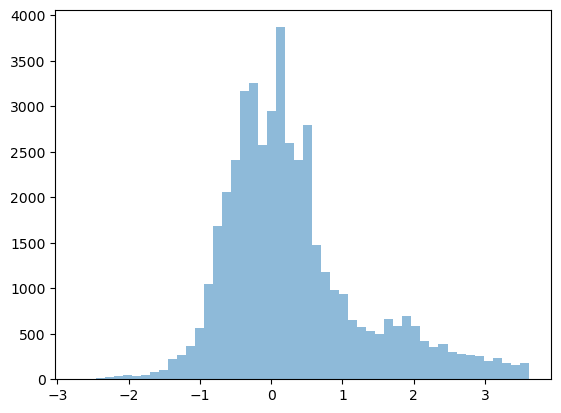

```python
# Representamos los datos normalizados para ver el rango y la distribución de los datos
plt.hist(santmiquel_data_normal.co2_norm, bins=50, alpha=0.5, label='Datos normalizados')
plt.show()
```

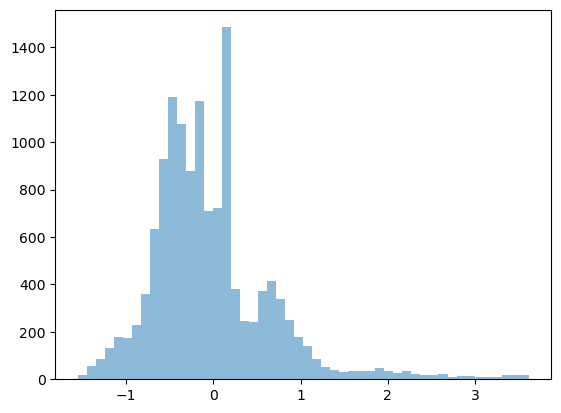

```python
plt.hist(albea_data_normal_01_02.co2_norm, bins=50, alpha=0.5, label='Datos normalizados (val set)')
plt.show()
```

```python
# Guardamos el scaler ajustado para poder llevarlo a la plataforma de despliegue
joblib.dump(scaler, 'scaler.save')
```

```
['scaler.save']
```

```python
# Definimos esta función para agrupar nuestros datos de entrenamiento y validación en sliding windows de tamaño t (Necesario para los modelos LSTM-AE)
def create_sets(t):
    # Creamos el conjunto de train
    train_data = np.array([]).reshape(0,t)
    sensors_santmiquel = santmiquel_data_normal.sensor_id.unique()
    for sensor in sensors_santmiquel:
        sensor_data = santmiquel_data_normal[(santmiquel_data_normal['sensor_id'] == sensor)].co2_norm.to_numpy()
        n = len(sensor_data)
        # Con este código creamos las subsecuencias con desplazamiento 1
        sliding_window = np.array([sensor_data[i:i+t] for i in range(n-t+1)])
        train_data = np.concatenate((train_data, sliding_window))

    # Creamos el conjunto de val
    sensors_val = albea_data_normal_01_02.sensor_id.unique()
    val_data = np.array([]).reshape(0,t)
    for sensor in sensors_val:
        sensor_data = albea_data_normal_01_02[albea_data_normal_01_02['sensor_id'] == sensor]
        co2_data = sensor_data.co2_norm.to_numpy()
        n = len(co2_data)
        sliding_window = np.array([co2_data[i:i+t] for i in range(n-t+1)])
        val_data = np.concatenate((val_data, sliding_window))

    # Para test vamos a crear un dataset para los datos y otro para los labels y no necesitamos sliding. Aún así se crean subsecuencias de tamaño t, para alimentar a los modelos
    sensors_test = albea_data_03_06.sensor_id.unique()
    test_data = np.array([]).reshape(0,t)
    test_data_norm = np.array([]).reshape(0,t)
    test_data_labels = np.array([]).reshape(0,t)
    for sensor in sensors_test:
        sensor_data = albea_data_03_06[albea_data_03_06['sensor_id'] == sensor]
        co2_data = sensor_data.co2.to_numpy()
        co2_data_norm = sensor_data.co2_norm.to_numpy()
        label_data = sensor_data.target.to_numpy()
        n = len(co2_data)
        n_norm = len(co2_data_norm)
        # Se crean subsecuencias de tamaño t pero sin que se solapen los datos
        sliding_window = np.array([co2_data[i*t:i*t+t] for i in range(int(np.floor(n/t)))])
        sliding_window_norm = np.array([co2_data_norm[i*t:i*t+t] for i in range(int(np.floor(n_norm/t)))])
        sliding_window_labels = np.array([label_data[i*t:i*t+t] for i in range(int(np.floor(n/t)))])
        test_data = np.concatenate((test_data, sliding_window))
        test_data_norm = np.concatenate((test_data_norm, sliding_window_norm))
        test_data_labels = np.concatenate((test_data_labels, sliding_window_labels))
    test_data_labels = test_data_labels.astype(int)
    return train_data, val_data, test_data, test_data_norm, test_data_labels
```

```python
# Con esta función creamos los conjuntos de train, val y test para los modelos no supervisados que no necesitan limpiar las anomalías de los conjuntos de train ni sliding windows
def create_unrolled_sets():
    train_data = np.array([])
    # Nota: Se utiliza el dataset con todos los datos
    santmiquel_data = final_dataset_full[final_dataset_full.location == 'santmiquel']
    sensors_santmiquel = santmiquel_data.sensor_id.unique()
    for sensor in sensors_santmiquel:
        sensor_data = santmiquel_data[santmiquel_data['sensor_id'] == sensor]
        co2_data = sensor_data.co2_norm.to_numpy()
        train_data = np.concatenate((train_data, co2_data))

    albea_data = final_dataset_full[final_dataset_full.location == 'albea']
    sensors_albea = albea_data.sensor_id.unique()
    # Se seleccionan los dos primeros sensores de Albea para el entrenamiento ya que no tenemos conjunto de validación en este caso
    for sensor in sensors_albea[0:2]:
        sensor_data = albea_data[albea_data['sensor_id'] == sensor]
        co2_data = sensor_data.co2_norm.to_numpy()
        train_data = np.concatenate((train_data, co2_data))

    test_data = np.array([])
    test_data_norm = np.array([])
    test_data_labels = np.array([])
    # Para test guardamos los valores sin normalizar, normalizados y las labels
    for sensor in sensors_albea[2:]:
        sensor_data = albea_data[albea_data['sensor_id'] == sensor]
        co2_data = sensor_data.co2.to_numpy()
        co2_data_norm = sensor_data.co2_norm.to_numpy()
        label_data = sensor_data.target.to_numpy()
        test_data = np.concatenate((test_data, co2_data))
        test_data_norm = np.concatenate((test_data_norm, co2_data_norm))
        test_data_labels = np.concatenate((test_data_labels, label_data))
    test_data_labels = test_data_labels.astype(int)
    return train_data, test_data, test_data_norm, test_data_labels
```

```python
## Por si se quieren guardar las secuencias en fichero
# np.savetxt('train_data_lstm_ae.csv', train_data, delimiter=',')
# np.savetxt('val_data_lstm_ae.csv', val_data, delimiter=',')
# np.savetxt('test_data_lstm_ae.csv', test_data, delimiter=',')
# np.savetxt('test_data_norm_lstm_ae.csv', test_data_norm, delimiter=',')
# np.savetxt('test_data_labels_lstm_ae.csv', test_data_labels, delimiter=',')
```

```python
# Elegimos el sensor CO2_04 de Albea para guardarlo en un fichero de cabecera de lenguaje C e introducirlo en el Microcontrolador
sensor_data = albea_data_03_06[albea_data_03_06['sensor_id'] == 'CO2_04']
co2_data = sensor_data.co2.to_numpy()
array = 'static float input_data[' + str(len(co2_data)) + '] = {'
for i, val in enumerate(co2_data):
    array += str(val)
    if i != len(co2_data)-1:
        array += ', '
array += '};'

#print(array)
with open('sensor_data.h', 'w') as file:
        file.write(array)
```

## 6 - Modelo Cloud: LSTM-AE

En este apartado crearemos el modelo LSTM-AE con 3 capas LSTM que irá en la parte del servidor

```python
THRESHOLD = 999 # Establecemos un valor de umbral inicial (NO tiene importancia, es solo para tener un valor de referencia)
```

```python
# Definimos una función que devuelva los errores de reconstrucción y el error máximo
def get_threshold(model, data):
    mae = tf.keras.losses.MeanAbsoluteError(reduction=tf.keras.losses.Reduction.NONE) # No aplicamos reducción para que nos devuelva toda la lista
    prediction = model.predict(data, verbose=0)
    losses = mae(data,prediction).numpy()
    max_loss = losses.max()
    return max_loss, losses
```

```python
# Función que recibe un array con los errores de la predicción y devuelve un array indicando las anomalías
def predict_anomaly_keras(losses, threshold = THRESHOLD):
    predictions, losses_array, anomalies_array = [], [], []
    for losses_timestep in losses:
        anomaly = []
        for loss in losses_timestep:
            if loss > threshold:
                anomaly.append(1)
            else:
                anomaly.append(0)

        anomalies_array.append(anomaly)
    return np.array(anomalies_array)
```

```python
# Función que recibe el modelo y los datos y labels y devuelve una seríe de métricas acerca del rendimiento del modelo
def get_metrics(model, data, labels, t, threshold = THRESHOLD):
    metrics = {}
    total_count = 0
    TP = 0
    TN = 0
    FP = 0
    FN = 0
    # Se realiza la predicción y se obtiene la lista de anomalías detectadas por el modelo
    mae = tf.keras.losses.MeanAbsoluteError(reduction=tf.keras.losses.Reduction.NONE)
    prediction = model.predict(data.reshape(-1,t,1), verbose=0)
    losses = mae(data.reshape(-1,t,1),prediction).numpy()
    anomalies = predict_anomaly_keras(losses, threshold)
    # Se comparan las predicciones del modelo y las anomalías reales
    for real_data, pred_data in zip(labels, anomalies):
        for real_i, pred_i in zip(real_data, pred_data):
            if real_i == pred_i:
                if real_i == 0:
                    TN += 1
                else:
                    TP += 1
            else:
                if real_i == 0:
                    FN += 1
                else:
                    FP += 1
            total_count += 1
    metrics['TP'] = TP
    metrics['TN'] = TN
    metrics['FP'] = FP
    metrics['FN'] = FN
    metrics['accuracy'] = (TN+TP)/total_count
    metrics['precision'] = TP/(TP+FP)
    metrics['recall'] = TP/(TP+FN)
    metrics['f1_score'] = 2 * (metrics['precision']*metrics['recall']/(metrics['precision']+metrics['recall']))
    return metrics
```

#### Utilizamos optuna para seleccionar los mejores parámetros.

```python
# Definimos la función objetivo para realizar nuestro estudio de Optuna
def objective(trial):
    # Definimos el espacio de búsqueda para los hiperparámetros
    units_1 = trial.suggest_categorical('units_1', [64, 128])
    t = trial.suggest_categorical('t', [5, 12, 20])
    learning_rate = trial.suggest_categorical('learning_rate', [0.001, 0.0001])
    batch_size = trial.suggest_categorical('batch_size', [32, 64])

    # Creamos el modelo LSTM
    LSTM_model = tf.keras.models.Sequential()
    LSTM_model.add(tf.keras.Input(shape=(t, 1)))

    LSTM_model.add(tf.keras.layers.LSTM(units=units_1, return_sequences=True))
    LSTM_model.add(tf.keras.layers.LSTM(units=int(units_1/2), return_sequences=True))
    LSTM_model.add(tf.keras.layers.LSTM(units=int(units_1/4)))
    LSTM_model.add(tf.keras.layers.RepeatVector(t))
    LSTM_model.add(tf.keras.layers.LSTM(units=int(units_1/4), return_sequences=True))
    LSTM_model.add(tf.keras.layers.LSTM(units=int(units_1/2), return_sequences=True))
    LSTM_model.add(tf.keras.layers.LSTM(units=units_1, return_sequences=True))
    LSTM_model.add(tf.keras.layers.TimeDistributed(tf.keras.layers.Dense(units = 1)))

    # Compilamos el modelo
    LSTM_model.compile(optimizer=tf.keras.optimizers.Adam(learning_rate=learning_rate),
                       loss=tf.keras.losses.MeanAbsoluteError())

    # Creamos los datos con sliding
    train_data, val_data, test_data, test_data_norm, test_data_labels = create_sets(t)
    train_df = train_data.reshape(-1,t,1)
    val_df = val_data.reshape(-1,t,1)
    # Entrenamos el modelo. El número de epoch es reducido para mantener los tiempos en un rango asumible
    history = LSTM_model.fit(train_df, train_df,
                             epochs=30,
                             batch_size=batch_size,
                             validation_data=(val_df, val_df),
                             callbacks=[
                                 tf.keras.callbacks.EarlyStopping(monitor='val_loss', patience=5, restore_best_weights=True)
                             ],
                             shuffle=False, verbose = 0)
    max_loss, losses = get_threshold(LSTM_model, val_df)
    # Devolvemos la pérdida máxima
    return max_loss
```

```python
# Realizamos el estudio, buscamos minimizar el error de reconstrucción máximo
study = optuna.create_study(direction='minimize')
study.optimize(objective, n_trials=12)
```

```
[I 2023-05-20 12:12:55,589] A new study created in memory with name: no-name-617bd42b-9c1d-41d0-bda2-551f85287a0c
[I 2023-05-20 12:23:33,381] Trial 0 finished with value: 3.549907922744751 and parameters: {'units_1': 128, 't': 20, 'learning_rate': 0.0001, 'batch_size': 32}. Best is trial 0 with value: 3.549907922744751.
[I 2023-05-20 12:34:11,051] Trial 1 finished with value: 3.4043335914611816 and parameters: {'units_1': 128, 't': 12, 'learning_rate': 0.0001, 'batch_size': 32}. Best is trial 1 with value: 3.4043335914611816.
[I 2023-05-20 12:44:47,514] Trial 2 finished with value: 3.530564546585083 and parameters: {'units_1': 128, 't': 20, 'learning_rate': 0.0001, 'batch_size': 32}. Best is trial 1 with value: 3.4043335914611816.
[I 2023-05-20 12:55:25,354] Trial 3 finished with value: 3.764374256134033 and parameters: {'units_1': 64, 't': 20, 'learning_rate': 0.0001, 'batch_size': 32}. Best is trial 1 with value: 3.4043335914611816.
[I 2023-05-20 13:02:02,807] Trial 4 finished with value: 3.62886118888855 and parameters: {'units_1': 128, 't': 20, 'learning_rate': 0.0001, 'batch_size': 64}. Best is trial 1 with value: 3.4043335914611816.
[I 2023-05-20 13:08:39,981] Trial 5 finished with value: 3.699599266052246 and parameters: {'units_1': 128, 't': 20, 'learning_rate': 0.0001, 'batch_size': 64}. Best is trial 1 with value: 3.4043335914611816.
[I 2023-05-20 13:19:17,260] Trial 6 finished with value: 3.504138231277466 and parameters: {'units_1': 128, 't': 20, 'learning_rate': 0.0001, 'batch_size': 32}. Best is trial 1 with value: 3.4043335914611816.
[I 2023-05-20 13:24:54,726] Trial 7 finished with value: 3.9209415912628174 and parameters: {'units_1': 64, 't': 12, 'learning_rate': 0.001, 'batch_size': 64}. Best is trial 1 with value: 3.4043335914611816.
[I 2023-05-20 13:30:32,012] Trial 8 finished with value: 3.936558485031128 and parameters: {'units_1': 64, 't': 12, 'learning_rate': 0.001, 'batch_size': 64}. Best is trial 1 with value: 3.4043335914611816.
[I 2023-05-20 13:35:33,596] Trial 9 finished with value: 3.673919916152954 and parameters: {'units_1': 128, 't': 12, 'learning_rate': 0.001, 'batch_size': 64}. Best is trial 1 with value: 3.4043335914611816.
[I 2023-05-20 13:45:11,062] Trial 10 finished with value: 0.7090426683425903 and parameters: {'units_1': 128, 't': 5, 'learning_rate': 0.001, 'batch_size': 32}. Best is trial 10 with value: 0.7090426683425903.
[I 2023-05-20 13:51:53,656] Trial 11 finished with value: 3.1036298274993896 and parameters: {'units_1': 128, 't': 5, 'learning_rate': 0.001, 'batch_size': 32}. Best is trial 10 with value: 0.7090426683425903.
```

```python
# Obtenemos los mejores parámetros del estudio
best_params = study.best_params
best_f1 = study.best_value
print(best_params)
print(best_f1)
```

```
{'units_1': 128, 't': 5, 'learning_rate': 0.001, 'batch_size': 32}
0.7090426683425903
```

```python
# Visualizamos la historia de la optimización
optuna_visualization.plot_optimization_history(study)
```

[interactive chart not shown]

```python
# Visualizamos la importancia de los hiperparámetros
optuna_visualization.plot_param_importances(study)
```

[interactive chart not shown]

```python
# Decidimos quedarnos con t = 6 (media hora de secuencia)
t = 6
# Creamos el conjunto de datos
train_data, val_data, test_data, test_data_norm, test_data_labels = create_sets(t)
train_df = train_data.reshape(-1,t,1)
val_df = val_data.reshape(-1,t,1)
```

```python
# Creamos nuestro modelo LSTM-AE con los parámetros optimizados
LSTM_model = tf.keras.models.Sequential()
LSTM_model.add(tf.keras.Input(shape=(t, 1)))
LSTM_model.add(tf.keras.layers.LSTM(units=64, return_sequences=True))
LSTM_model.add(tf.keras.layers.LSTM(units=32, return_sequences=True))
LSTM_model.add(tf.keras.layers.LSTM(units=16))
LSTM_model.add(tf.keras.layers.RepeatVector(t))
LSTM_model.add(tf.keras.layers.LSTM(units=16, return_sequences=True))
LSTM_model.add(tf.keras.layers.LSTM(units=32, return_sequences=True))
LSTM_model.add(tf.keras.layers.LSTM(units=64, return_sequences=True))
LSTM_model.add(tf.keras.layers.TimeDistributed(tf.keras.layers.Dense(units = 1)))
LSTM_model.compile(
    optimizer = tf.keras.optimizers.Adam(learning_rate=0.001),
    loss = tf.keras.losses.MeanAbsoluteError(),
)
```

```python
LSTM_model.summary()
```

```
Model: "sequential"
_________________________________________________________________
 Layer (type)                Output Shape              Param #
=================================================================
 lstm (LSTM)                 (None, 6, 64)             16896

 lstm_1 (LSTM)               (None, 6, 32)             12416

 lstm_2 (LSTM)               (None, 16)                3136

 repeat_vector (RepeatVector  (None, 6, 16)            0
 )

 lstm_3 (LSTM)               (None, 6, 16)             2112

 lstm_4 (LSTM)               (None, 6, 32)             6272

 lstm_5 (LSTM)               (None, 6, 64)             24832

 time_distributed (TimeDistr  (None, 6, 1)             65
 ibuted)

=================================================================
Total params: 65,729
Trainable params: 65,729
Non-trainable params: 0
_________________________________________________________________
```

```python
# Realizamos el entrenamiento del modelo durante 200 epochs, pero si la pérdida del conjunto de val no mejora en 20 epochs
# Se se reduce el learning rate y se para si aún así no mejora
history = LSTM_model.fit(
    train_df, train_df,
    epochs = 200,
    batch_size = 32,
    validation_data=(val_df, val_df),
    callbacks=[
        tf.keras.callbacks.EarlyStopping(monitor='val_loss', patience=20, restore_best_weights=True),
        tf.keras.callbacks.ModelCheckpoint('checkpoint_lstm_ae.h5', monitor='val_loss', save_best_only=True),
        tf.keras.callbacks.ReduceLROnPlateau(monitor='val_loss', patience=20)
    ],
    shuffle=False
)
```

```python
# Se obtiene el umbral (El error de reconstrucción máximo) a partir del conjunto de validación
max_loss, losses = get_threshold(LSTM_model, val_df)
print(max_loss)
```

```
0.6844909
```

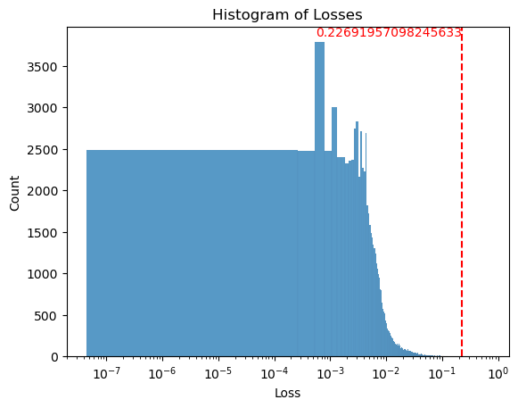

```python
# Representamos los errores de reconstrucción (con escala logarítmica en el eje x) y marcamos el percentil 99 (Solo para ver donde caen el 99% de los datos)
sns.histplot(losses.reshape(1,-1)[0], kde=False)
percentile_99 = np.percentile(losses.reshape(1,-1)[0], 99.9)
plt.axvline(percentile_99, color='red', linestyle='--', label='99th Percentile')
plt.text(percentile_99, plt.ylim()[1], percentile_99, color='red', verticalalignment='top', ha='right')
plt.xscale('log')
plt.xlabel('Loss')
plt.ylabel('Count')
plt.title('Histogram of Losses')
plt.show()
```

```python
# Establecemos el umbral
THRESHOLD = max_loss
```

```python
# Obtenemos las métricas sobre el conjunto de test
metrics = get_metrics(LSTM_model, test_data_norm, test_data_labels, t, THRESHOLD)
```

```python
print(metrics)
```

```
{'TP': 1625, 'TN': 23797, 'FP': 147, 'FN': 117, 'accuracy': 0.9897220275636534, 'precision': 0.9170428893905191, 'recall': 0.9328358208955224, 'f1_score': 0.9248719408081959}
```

```python
# Exportamos el modelo y sus pesos para poder cargarlo en el servidor de despliegue
model_json = LSTM_model.to_json()
with open("LSTM_model.json", "w") as json_file:
    json_file.write(model_json)
LSTM_model.save_weights("LSTM_model.h5")
```

```python
# Cargar modelo
with open("../input/models/LSTM_model.json") as f:
    model_json = f.read()
LSTM_model = tf.keras.models.model_from_json(model_json)
LSTM_model.load_weights("../input/models/LSTM_model.h5")
```

## 7 - Modelo Standalone: LSTM-AE

Realizamos la implementación del modelo LSTM-AE que irá embebido en el Microcontrolador. Este modelo tiene ciertas limitaciones marcadas por el entorno donde se realizará la inferencia. En primer lugar se limitan el número de capas LSTM a 2 (1 en el codificador y otra en el decodificador), también se establece un número reducido de unidades (16), se eliminan las capas RepeatVector y TimeDistributed y se establece a 1 el batch size.

```python
# Creamos el modelo LSTM-AE de 1 capa
inputs = tf.keras.Input(shape=(t, 1), batch_size=1)
x = tf.keras.layers.LSTM(units=16, return_sequences=True)(inputs)
x = tf.keras.layers.LSTM(units=16, return_sequences=True)(x)
outputs = tf.keras.layers.Dense(1)(x)
LSTM_standalone_model = tf.keras.Model(inputs=inputs, outputs=outputs)
LSTM_standalone_model.compile(
    optimizer = tf.keras.optimizers.Adam(learning_rate=0.001),
    loss = tf.keras.losses.MeanAbsoluteError(),
)
```

```python
LSTM_standalone_model.summary()
```

```
Model: "model"
_________________________________________________________________
 Layer (type)                Output Shape              Param #
=================================================================
 input_2 (InputLayer)        [(1, 6, 1)]               0

 lstm_6 (LSTM)               (1, 6, 16)                1152

 lstm_7 (LSTM)               (1, 6, 16)                2112

 dense_1 (Dense)             (1, 6, 1)                 17

=================================================================
Total params: 3,281
Trainable params: 3,281
Non-trainable params: 0
_________________________________________________________________
```

```python
# En este caso se utilizan menos épocas de entrenamiento ya que el batch_size de 1 ralentiza enormemente el proceso de entrenamiento
history = LSTM_standalone_model.fit(
    train_df, train_df,
    epochs = 30,
    batch_size = 1,
    validation_data=(val_df, val_df),
    callbacks=[
        tf.keras.callbacks.EarlyStopping(monitor='val_loss', patience=5, restore_best_weights=True),
        tf.keras.callbacks.ModelCheckpoint('checkpoint_lstm_ae.h5', monitor='val_loss', save_best_only=True)
    ],
    shuffle=False
)
```

```python
# Calculamos el umbral del error de reconstrucción. No podemos usar la función get_threshold definida anteriormente porque este modelo no puede recibir datos en lotes
mae = tf.keras.losses.MeanAbsoluteError(reduction=tf.keras.losses.Reduction.NONE)
losses = []
for input_data in val_df:
    prediction = LSTM_standalone_model.predict(np.array([input_data]), verbose=0)
    losses.append(np.max(mae(input_data,prediction).numpy()))
THRESHOLD_STANDALONE = np.array(losses).max()
print(THRESHOLD_STANDALONE)
```

```
0.102877855
```

```python
# Función que recibe el modelo y los datos y labels y devuelve una seríe de métricas acerca del rendimiento del modelo
def get_metrics_standalone(model, data, labels, t, threshold = THRESHOLD):
    metrics = {}
    total_count = 0
    TP = 0
    TN = 0
    FP = 0
    FN = 0
    # Se realiza la predicción y se obtiene la lista de anomalías detectadas por el modelo (En este caso se debe pasar cada secuencia por separado, ya que no tenemos batch)
    mae = tf.keras.losses.MeanAbsoluteError(reduction=tf.keras.losses.Reduction.NONE)
    labels = labels.reshape(-1,t,1)
    for i, input_data in enumerate(data.reshape(-1,t,1)):
        prediction = model.predict(np.array([input_data]), verbose=0)
        losses = mae(input_data,prediction).numpy()
        anomalies = predict_anomaly_keras(losses, threshold)
        # Se comparan las predicciones del modelo y las anomalías reales
        for real_data, pred_data in zip(labels[i], anomalies):
            for real_i, pred_i in zip(real_data, pred_data):
                if real_i == pred_i:
                    if real_i == 0:
                        TN += 1
                    else:
                        TP += 1
                else:
                    if real_i == 0:
                        FN += 1
                    else:
                        FP += 1
                total_count += 1
    metrics['TP'] = TP
    metrics['TN'] = TN
    metrics['FP'] = FP
    metrics['FN'] = FN
    metrics['accuracy'] = (TN+TP)/total_count
    metrics['precision'] = TP/(TP+FP)
    metrics['recall'] = TP/(TP+FN)
    metrics['f1_score'] = 2 * (metrics['precision']*metrics['recall']/(metrics['precision']+metrics['recall']))
    return metrics
```

```python
# Obtenemos las métricas sobre el conjunto de test
metrics = get_metrics_standalone(LSTM_standalone_model, test_data_norm, test_data_labels, t, THRESHOLD_STANDALONE)
print(metrics)
```

```
{'TP': 254, 'TN': 3995, 'FP': 32, 'FN': 0, 'accuracy': 0.9925251109553842, 'precision': 0.8881118881118881, 'recall': 1.0, 'f1_score': 0.9407407407407408}
```

```python
# Convertimos el modelo Keras a un modelo de Tensorflow Lite
converter = tf.lite.TFLiteConverter.from_keras_model(LSTM_standalone_model)
converter._experimental_default_to_single_batch_in_tensor_list_ops = True
tflite_model = converter.convert()
```

```python
# Exportamos el modelo keras
model_json = LSTM_standalone_model.to_json()
with open("LSTM_standalone_model.json", "w") as json_file:
    json_file.write(model_json)
LSTM_standalone_model.save_weights("LSTM_standalone_model.h5")
```

```python
# Cargar modelo
with open("../input/models/LSTM_standalone_model.json") as f:
    model_json = f.read()
LSTM_standalone_model = tf.keras.models.model_from_json(model_json)
LSTM_standalone_model.load_weights("../input/models/LSTM_standalone_model.h5")
```

```python
# Guardamos el modelo de Tensorflow Lite
with open('model_autoencoder.tflite', 'wb') as f:
    f.write(tflite_model)
```

```python
# Convertimos el modelo de TFLite a un fichero de c++
!xxd -i model_autoencoder.tflite > model.cc
```

## 8 - Isolation Forest

En este apartado se crea el modelo Isolation Forest. Este modelo no necesita limpiar las anomalías del conjunto de train, pero tampoco es capaz de capturar patrones temporales en los datos.

```python
# Cargamos los datos
train_data, test_data, test_data_norm, test_data_labels = create_unrolled_sets()
```

```python
# Creamos el modelo y lo entrenamos
iso_model = IsolationForest(n_estimators=100, max_samples=len(train_data), contamination=0.0594,random_state=RANDOM_SEED, verbose=0)
iso_model.fit(train_data.reshape(-1,1))
scores_prediction = iso_model.decision_function(train_data.reshape(-1,1))
print(scores_prediction)
```

```
[-0.01248008 -0.03051985  0.00691577 ...  0.11337447  0.11644915
  0.11152931]
```

```python
# Definimos una función similar a la de get_metrics pero para modelos de sklearn
def get_metrics_sklearn(model, data, labels):
    metrics = {}
    total_count = 0
    metrics['TP'] = 0
    metrics['TN'] = 0
    metrics['FP'] = 0
    metrics['FN'] = 0
    anomalies = model.predict(data.reshape(-1,1))
    anomalies[anomalies == 1] = 0
    anomalies[anomalies == -1] = 1
    for real_data, pred_data in zip(labels, anomalies):
        if real_data == pred_data:
            if real_data == 0:
                metrics['TN'] += 1
            else:
                metrics['TP'] += 1
        else:
            if real_data == 0:
                metrics['FN'] += 1
            else:
                metrics['FP'] += 1
        total_count += 1
    metrics['accuracy'] = (metrics['TN']+metrics['TP'])/total_count
    metrics['precision'] = metrics['TP']/(metrics['TP']+metrics['FP'])
    metrics['recall'] = metrics['TP']/(metrics['TP']+metrics['FN'])
    metrics['f1_score'] = 2 * (metrics['precision']*metrics['recall']/(metrics['precision']+metrics['recall']))
    return metrics
```

```python
# Obtenemos las métricas del modelo Isolation Forest sobre el conjunto de test
iso_metrics = get_metrics_sklearn(iso_model, test_data_norm, test_data_labels)
print(iso_metrics)
```

```
{'TP': 1506, 'TN': 23793, 'FP': 266, 'FN': 123, 'accuracy': 0.9848567424478356, 'precision': 0.8498871331828443, 'recall': 0.9244935543278084, 'f1_score': 0.8856218759188473}
```

## 9 - OC-SVM

Al igual que el anterior modelo, el OneClass-SVM es un modelo simple que no necesita que se limpien las anomalías del conjunto de train pero no es capaz de encontrar patrones temporales en los datos.

```python
# Creamos el modelo con los mejores hiperparámetros y lo entrenamos
svm_model = OneClassSVM(gamma=0.001, nu=0.0594, max_iter=-1)
svm_model.fit(train_data.reshape(-1,1))
```

```
OneClassSVM(gamma=0.001, nu=0.0594)
```

```python
# Obtenemos las métricas del modelo OC-SVM
svm_metrics = get_metrics_sklearn(svm_model, test_data_norm, test_data_labels)
print(svm_metrics)
```

```
{'TP': 1088, 'TN': 23879, 'FP': 684, 'FN': 37, 'accuracy': 0.9719324198069137, 'precision': 0.6139954853273137, 'recall': 0.9671111111111111, 'f1_score': 0.7511218501898516}
```

```python
## Por si queremos guardar los datos de entrenamiento y test
# np.savetxt('train_data_norm_sequential.csv', train_data, delimiter=',')
# np.savetxt('test_data_norm_sequential.csv', test_data_norm, delimiter=',')
# np.savetxt('test_data_labels_sequential.csv', test_data_labels, delimiter=',')
```

```python
# Utilizamos la librería MicroMLGen para exportar el modelo a c++ por si queremos utilizarlo en el Microcontrolador
with open('one_class_svm.h', 'w') as file:
        file.write(port(svm_model))
```

## 10 - Comparativa de modelos

En este apartado se muestra una comparativa de las métricas obtenidas de cada modelo. Además se muestra la curva ROC de los 4 modelos.

| **Modelo** | **TP** | **TN** | **FP** | **FN** | **Accuracy** | **Precision** | **Recall** | **F1-score** |
| --- | --- | --- | --- | --- | --- | --- | --- | --- |
| LSTM-AE (Cloud) | 1625 | 23797 | 147 | 117 | 0.99 | 0.917 | 0.933 | 0.925 |
| LSTM-AE (Standalone) | 254 | 3995 | 32 | 0 | 0.993 | 0.888 | 1 | 0.941 |
| Isolation Forest | 1506 | 23793 | 266 | 123 | 0.985 | 0.85 | 0.924 | 0.886 |
| OC-SVM | 1088 | 23879 | 684 | 37 | 0.972 | 0.614 | 0.967 | 0.751 |

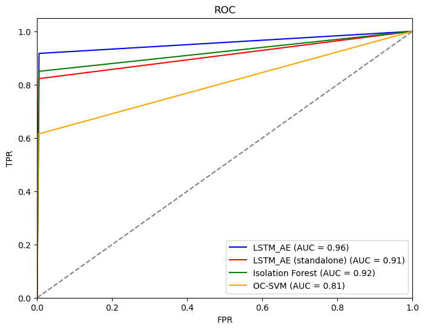

```python
# Modelo LSTM_AE cloud
mae = tf.keras.losses.MeanAbsoluteError(reduction=tf.keras.losses.Reduction.NONE)
train_data, val_data, test_data, test_data_norm, test_data_labels = create_sets(t)
prediction = LSTM_model.predict(test_data_norm.reshape(-1,t,1), verbose=0)
losses = mae(test_data_norm.reshape(-1,t,1),prediction).numpy()
anomalies = predict_anomaly_keras(losses, THRESHOLD)

fpr_lstm, tpr_lstm, _ = roc_curve(test_data_labels.reshape(1,-1)[0], anomalies.reshape(1, -1)[0])

# Modelo LSTM_AE standalone
losses = []
for i, input_data in enumerate(test_data_norm.reshape(-1,t,1)):
    prediction = LSTM_standalone_model.predict(np.array([input_data]), verbose=0)
    losses.append(mae(input_data,prediction).numpy()[0])
anomalies = predict_anomaly_keras(losses, THRESHOLD_STANDALONE)

fpr_lstm_standalone, tpr_lstm_standalone, _ = roc_curve(test_data_labels.reshape(1,-1)[0], anomalies.reshape(1, -1)[0])

# Modelo Isolation Forest
train_data, test_data, test_data_norm, test_data_labels = create_unrolled_sets()
anomalies = iso_model.predict(test_data_norm.reshape(-1,1))
anomalies[anomalies == 1] = 0
anomalies[anomalies == -1] = 1
fpr_iso_forest, tpr_iso_forest, _ = roc_curve(test_data_labels, anomalies)

# Modelo OC-SVM
anomalies = svm_model.predict(test_data_norm.reshape(-1,1))
anomalies[anomalies == 1] = 0
anomalies[anomalies == -1] = 1
fpr_oc_svm, tpr_oc_svm, _ = roc_curve(test_data_labels, anomalies)

# Calculamos el área bajo la curva ROC para cada modelo
auc_LSTM_AE_1 = auc(fpr_lstm, tpr_lstm)
auc_LSTM_AE_2 = auc(fpr_lstm_standalone, tpr_lstm_standalone)
auc_iso_forest = auc(fpr_iso_forest, tpr_iso_forest)
auc_oc_svm = auc(fpr_oc_svm, tpr_oc_svm)

# Representamos la curva de todos los modelos en la misma gráfica
plt.figure(figsize=(8, 6))
plt.plot(fpr_lstm, tpr_lstm, color='blue', label='LSTM_AE (AUC = %0.2f)' % auc_LSTM_AE_1)
plt.plot(fpr_lstm_standalone, tpr_lstm_standalone, color='red', label='LSTM_AE (standalone) (AUC = %0.2f)' % auc_LSTM_AE_2)
plt.plot(fpr_iso_forest, tpr_iso_forest, color='green', label='Isolation Forest (AUC = %0.2f)' % auc_iso_forest)
plt.plot(fpr_oc_svm, tpr_oc_svm, color='orange', label='OC-SVM (AUC = %0.2f)' % auc_oc_svm)
plt.plot([0, 1], [0, 1], color='gray', linestyle='--')
plt.xlim([0.0, 1.0])
plt.ylim([0.0, 1.05])
plt.xlabel('FPR')
plt.ylabel('TPR')
plt.title('ROC')
plt.legend(loc="lower right")
plt.show()
```